# Final Color for BRE

July 09, 2024

### Arrow charts without a grouping variable:

#### - With arrows in Blackstone dark blue “#283251”

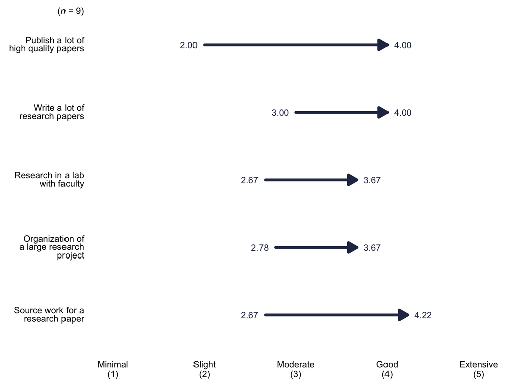

## Qualitative/Categorical Color Palette

### Example Swatch of the new Qualitative/Categorical Color Palette with 11 colors

#### - Most colors taken from `Okabe-Ito` palette, took out black and yellow and replaced with other colorblind friendly colors and the BRE dark blue.

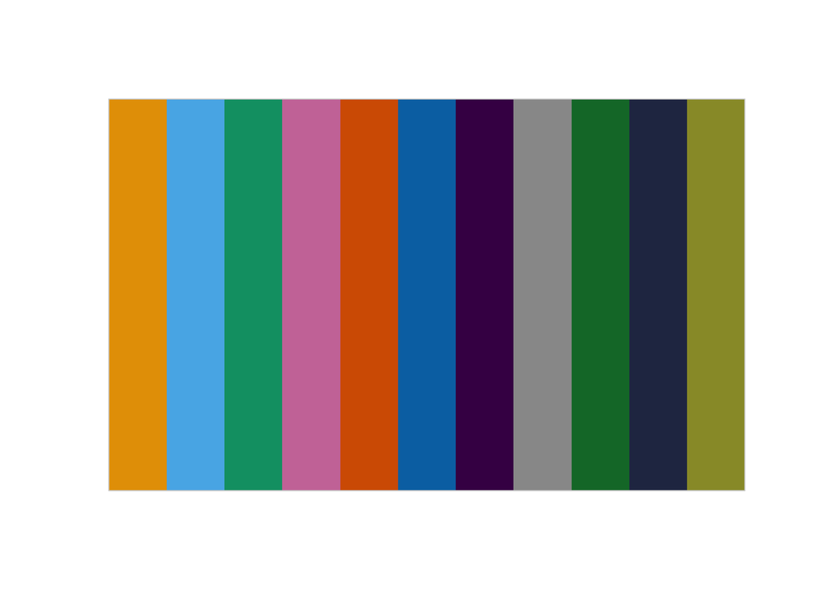

#### - Color palette with names and hex codes:

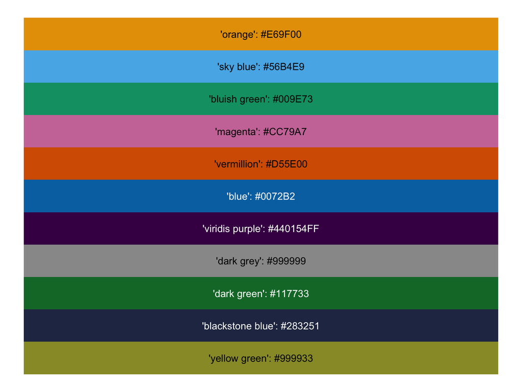

#### Hex codes for the full Qualitative Color Palette

`#E69F00`, `#56B4E9`, `#009E73`, `#CC79A7`, `#D55E00`, `#0072B2`, `#440154FF`, `#999999`, `#117733`, `#283251`, `#999933`

### Arrow chart with new custom qualitative color Palette based on `Okabe-Ito` colors:

#### - The “Overall” group will always be the color black

#### - This also shows what left/negative direction arrows would look like with the `Research` items.

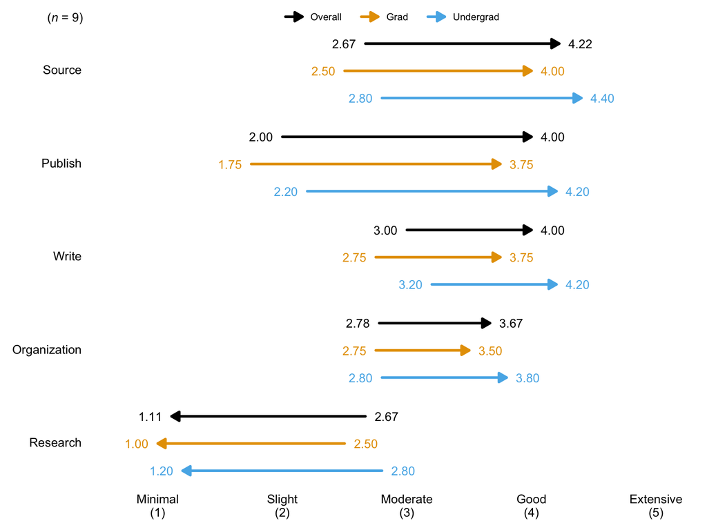

## Horizontal Bar Chart with 7 racial categories

### Horizontal Bar Chart with custom qualitative color Palette:

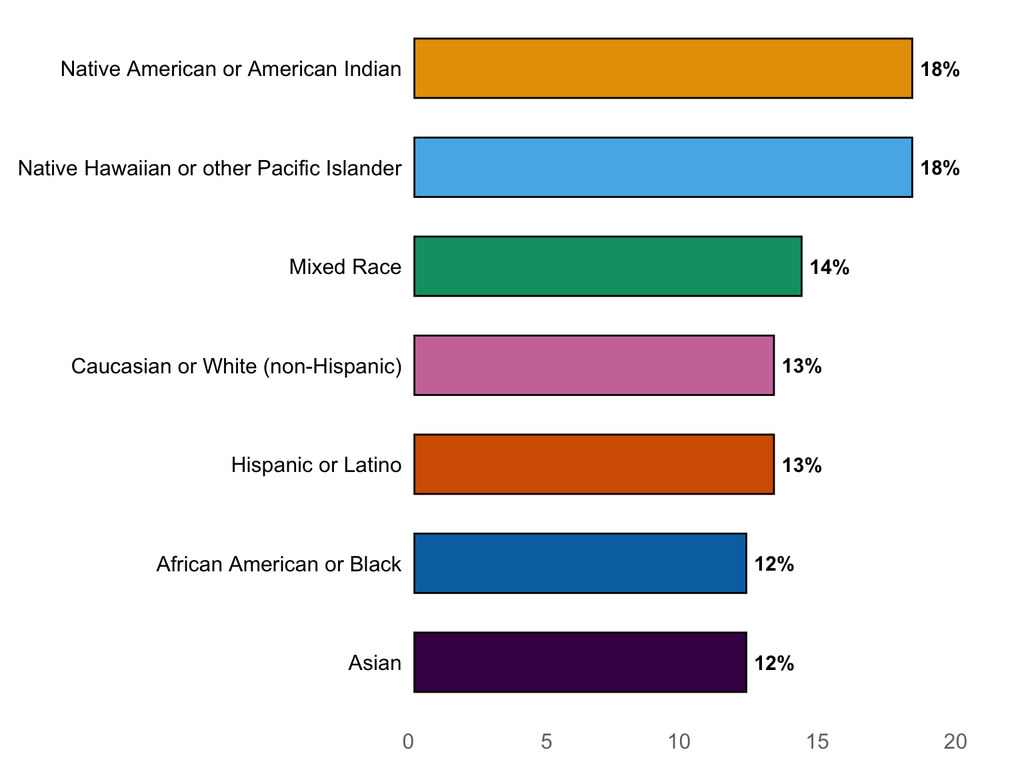

#### - Same palette, Only 3 categories:

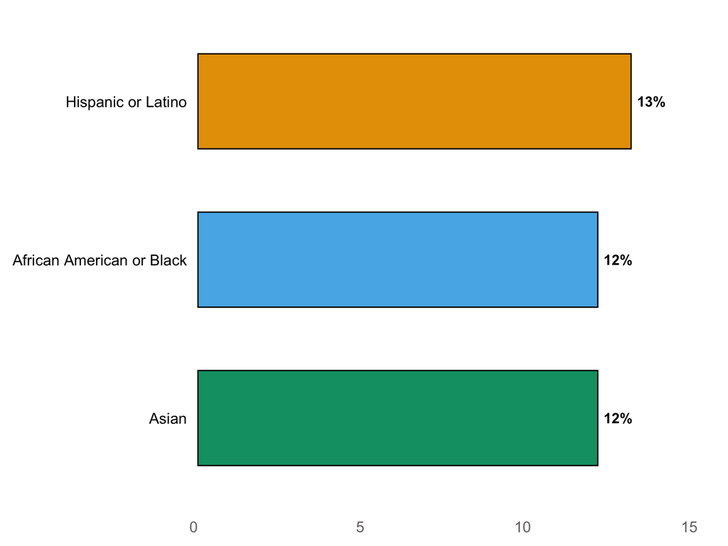

### Reversed color palette with 7 categories in horizontal bar chart to show bottom colors:

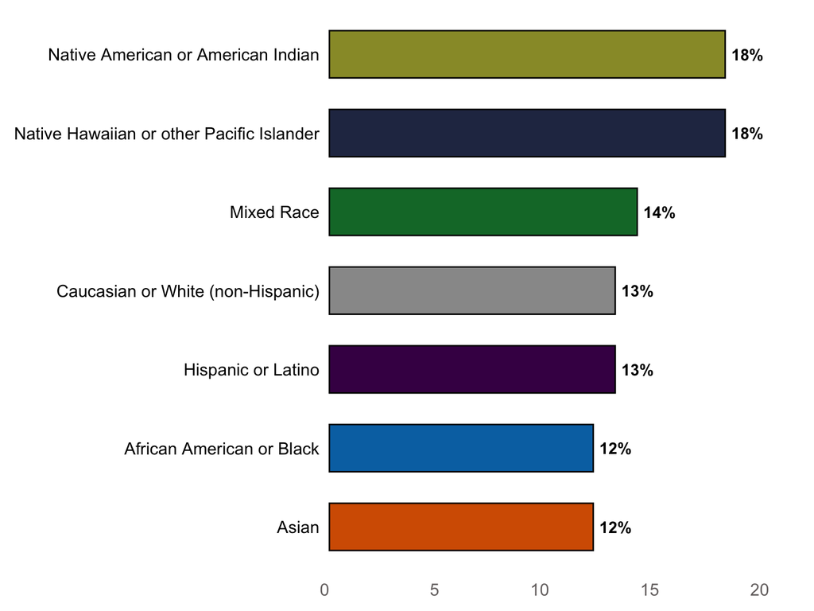

## Diverging Color Palette: slightly darkened `Blue Red 3`

### Stacked Pre-Post bar chart with `Blue Red 3` color palette on a 7 point scale:

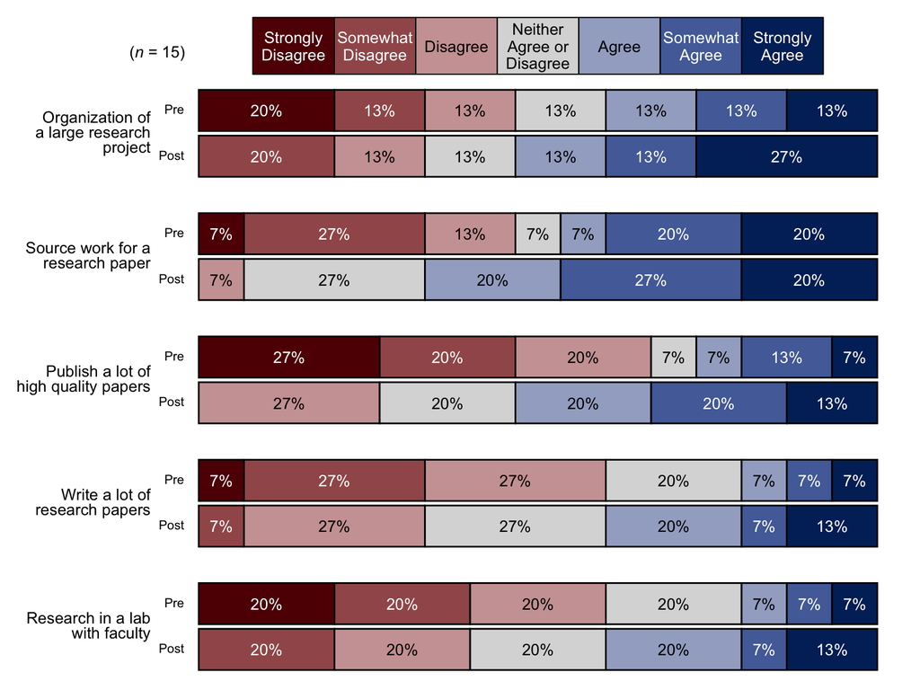

### Stacked bar chart (single items) with `Blue Red 3` color palette on a 7 point scale:

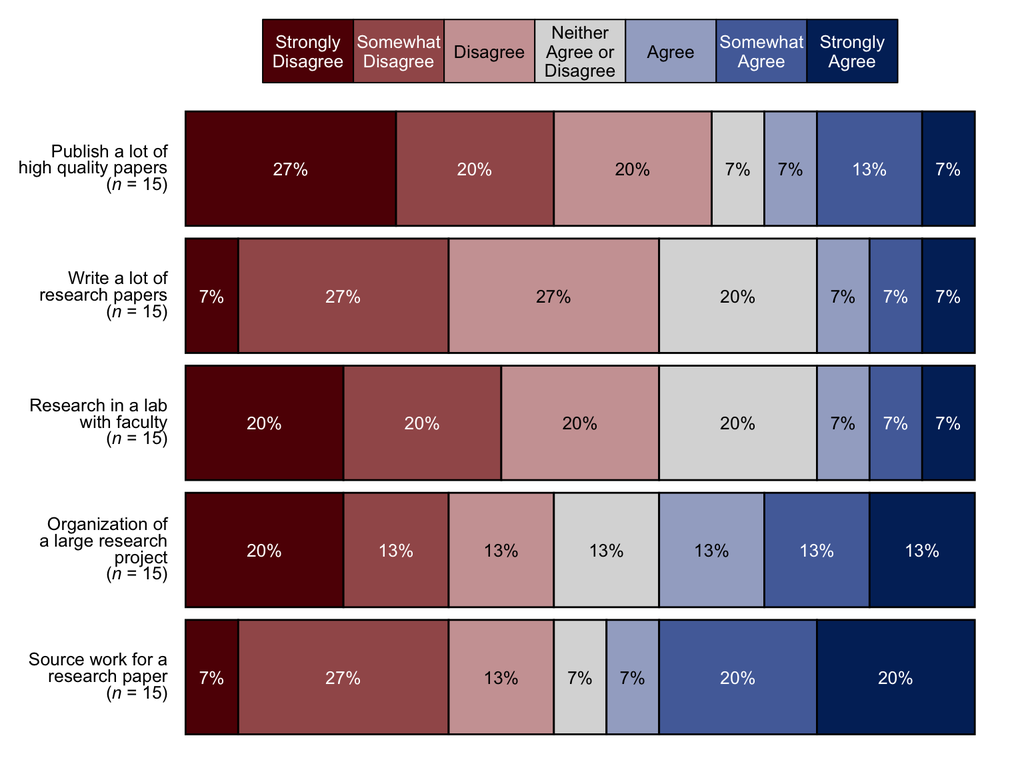

### Hex Codes for the Diverging Color Palette: Darkened `Blue Red 3`

#### **5 point scale:**

`#600204`, `#B88081`, `#DADADA`, `#7F8EB8`, `#012B67`

#### **7 point scale:**

`#600204`, `#A25959`, `#CDA2A3`, `#DADADA`, `#A3ADCB`, `#536DA8`, `#012B67`

## Sequential Color Scales: slightly darkened `Blues 3`

### Stacked bar chart with `Blues 3` color scale:

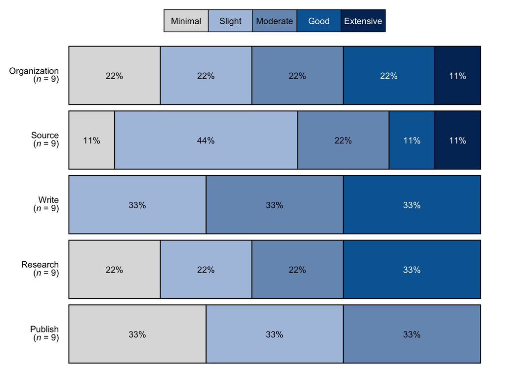

### Hex Codes for the Sequential Color Scale Darkened `Blues 3`

#### **5 point scale:**

`#DDDDDD`, `#AEC3DF`, `#7798BF`, `#0466A2`, `#023163`

#### **7 point scale:**

`#DDDDDD`, `#BDCFE6`, `#9FB5D5`, `#7798BF`, `#4677A7`, `#00548B`, `#023163`